# Using resmush

**resmush** is a **R** package that allow users to optimize and compress images using [**reSmush.it**](https://resmush.it/). reSmush.it is a free API that provides image optimization, and it has been implemented on Wordpress, Drupal or Magento.

Some of the features of **reSmush.it** are:

- Free optimization services, no API key required.
- Optimize local and online images.
- Image files supported: `png`, `jpg/jpeg`, `gif`, `bmp`, `tiff`.
- Max image size: 5 Mb.
- Compression via several algorithms:
  - [**PNGQuant**](https://pngquant.org/): Strip unneeded chunks from `png`s, preserving a full alpha transparency.
  - [**JPEGOptim**](https://github.com/tjko/jpegoptim)**:** Lossless optimization based on optimizing the Huffman tables.
  - [**OptiPNG**](https://optipng.sourceforge.net/): `png` reducer that is used by several online optimizers.

## Example

Compressing an online `jpg` image:

```r
library(resmush)

url <- paste0(
  "https://raw.githubusercontent.com/dieghernan/",
  "resmush/main/img/jpg_example_original.jpg"
)

resmush_url(url, outfile = "jpg_example_compress.jpg", overwrite = TRUE)
```

```
#> ══ resmush summary ═══════════════════════════════════════════════════════════════════════════════
#> ℹ Input: 1 url with size 178.7 Kb
#> ✔ Success for 1 url: Size now is 45 Kb (was 178.7 Kb). Saved 133.7 Kb (74.82%).
#> See result in directory '.'.
```

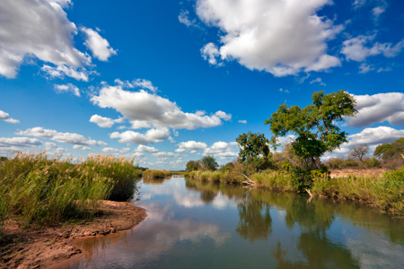

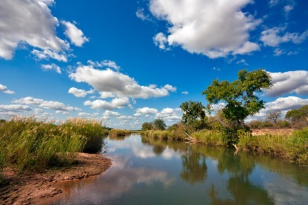

Original picture (top) 178.7 Kb and optimized picture (bottom) 45 Kb (Compression 74.8%). Click to enlarge.

The quality of the compression can be adjusted in the case of `jpg` files using the parameter `qlty`. However, it is recommended to keep this value above 90 to get a good image quality.

```r
# Extreme case
resmush_url(url,
  outfile = "jpg_example_compress_low.jpg",
  overwrite = TRUE, qlty = 3
)
```

```
#> ══ resmush summary ═══════════════════════════════════════════════════════════════════════════════
#> ℹ Input: 1 url with size 178.7 Kb
#> ✔ Success for 1 url: Size now is 2.2 Kb (was 178.7 Kb). Saved 176.4 Kb (98.74%).
#> See result in directory '.'.
```

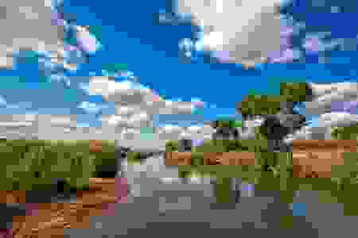

Low quality image due to a high compression rate.

All the functions return invisibly a data set with a summary of the process. The next example shows how when compressing a local file.

```r
png_file <- system.file("extimg/example.png", package = "resmush")

# For the example, copy to a temporary file
tmp_png <- tempfile(fileext = ".png")
file.copy(png_file, tmp_png, overwrite = TRUE)
```

```
#> [1] TRUE
```

```r
summary <- resmush_file(tmp_png)

tibble::as_tibble(summary[, -c(1, 2)])
```

```
#> # A tibble: 1 × 6
#>   src_size dest_size compress_ratio notes src_bytes dest_bytes
#>   <chr>    <chr>     <chr>          <chr>     <dbl>      <dbl>
#> 1 239.9 Kb 70.7 Kb   70.54%         OK       245618      72356
```

## Other alternatives

There are other alternatives for optimizing images with **R**:

- **xfun** (Xie 2024), which includes the following functions for optimizing image files:
  - `xfun::tinify()` is similar to `resmush_file()` but uses [**TinyPNG**](https://tinypng.com/). An API key is required.
  - `xfun::optipng()` compresses local files with **OptiPNG** (which needs to be installed locally).
- [**tinieR**](https://jmablog.github.io/tinieR/) package by [jmablog](https://jmablog.com/). An **R** package that provides a full interface with [**TinyPNG**](https://tinypng.com/).
- [**optout**](https://github.com/coolbutuseless/optout) package by [@coolbutuseless](https://coolbutuseless.github.io/). Similar to `xfun::optipng()` with more options. Requires additional software to be installed locally.

Table 1: **R** packages: Comparison of alternatives for optimizing images.

| tool | CRAN | Additional software? | Online? | API Key? | Limits? |
| --- | --- | --- | --- | --- | --- |
| `xfun::tinify()` | Yes | No | Yes | Yes | 500 files/month (Free tier) |
| `xfun::optipng()` | Yes | Yes | No | No | No |
| **tinieR** | No | No | Yes | Yes | 500 files/month (Free tier) |
| **optout** | No | Yes | No | No | No |
| **resmush** | Yes | No | Yes | No | Max size 5Mb |

Table 2: **R** packages: Formats admitted.

| tool | png | jpg | gif | bmp | tiff | webp | pdf |
| --- | --- | --- | --- | --- | --- | --- | --- |
| `xfun::tinify()` | ✅ | ✅ | ❌ | ❌ | ❌ | ✅ | ❌ |
| `xfun::optipng()` | ✅ | ❌ | ❌ | ❌ | ❌ | ❌ | ❌ |
| **tinieR** | ✅ | ✅ | ❌ | ❌ | ❌ | ✅ | ❌ |
| **optout** | ✅ | ✅ | ❌ | ❌ | ❌ | ❌ | ✅ |
| **resmush** | ✅ | ✅ | ✅ | ✅ | ✅ | ❌ | ❌ |

## References

Xie, Yihui. 2024. *xfun: Supporting Functions for Packages Maintained by Yihui Xie*. https://github.com/yihui/xfun.